# BM432 Data Visualisation Workshop

## Critique 3.1

**Issue**

Dynamite plot: the lower extent of these error bars is not visible.

**Solution**

Use boxplots or 1D scatterplots

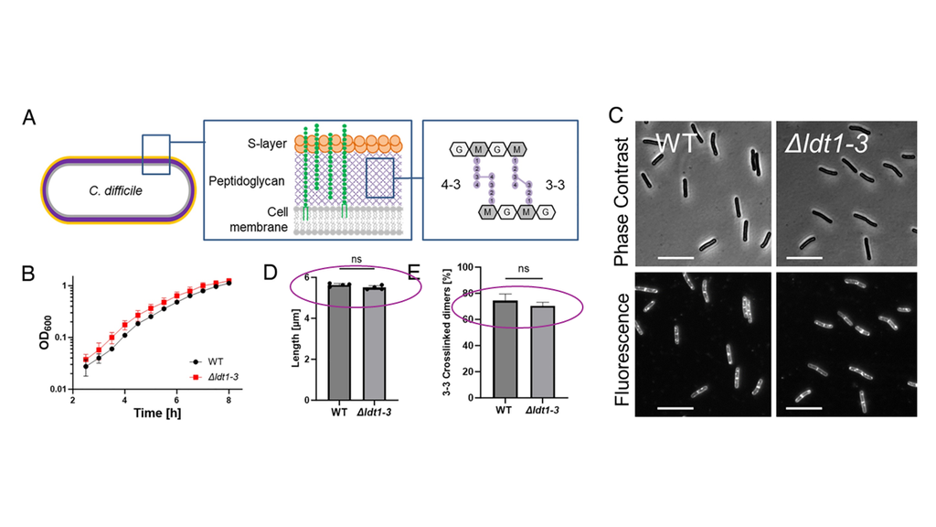

## Critique 3.2

**Issue**

No complement of the triple mutant strain - missing data for an essential control?

**Solution**

Ensure that all controls are presented so that the experimental result can be interpreted properly.

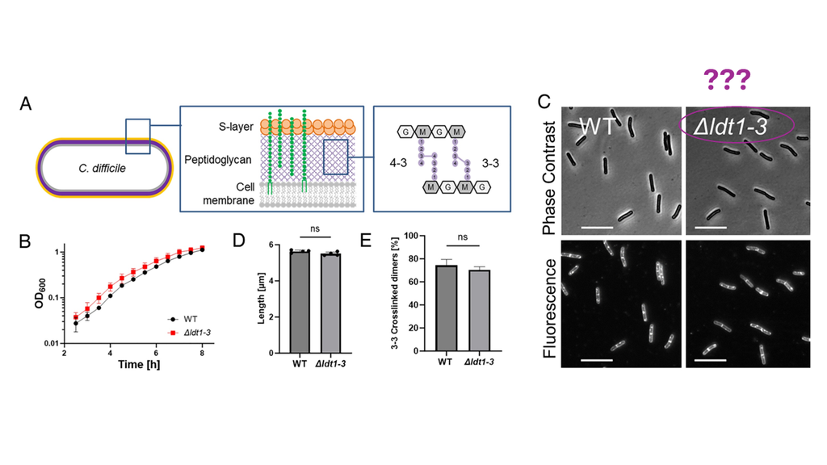

## Critique 3.3

**Issue**

Label obscures part of the image.

**Solution**

Relocate the label so data is not obscured.

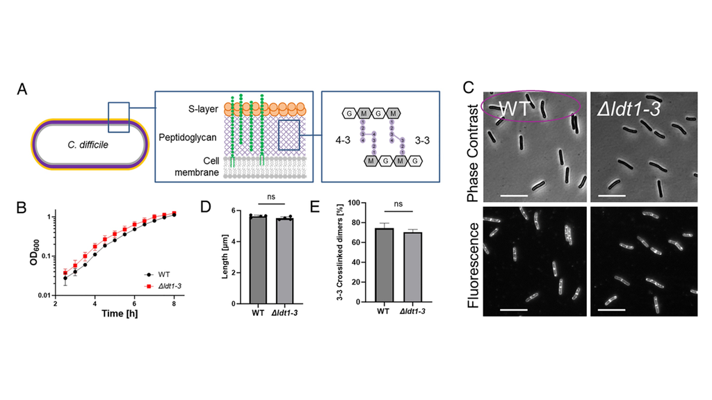

## Critique 3.4

**Issue**

Fluorescence wavelength not specified.

**Solution**

Include sufficient information that the reader does not need to refer to the main text. Overall a figure legend should provide enough detail for the figure to stand alone, but should not describe results/significance.

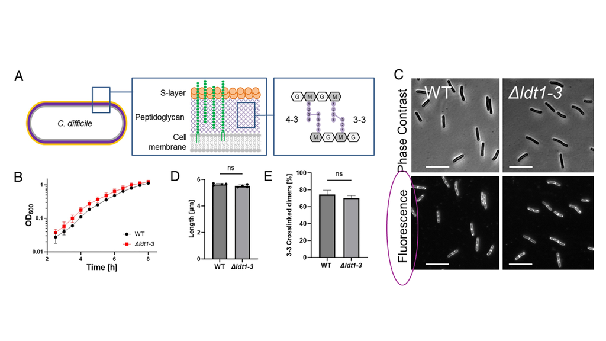

## Critique 3.5

**Issue**

Colour schemes/palettes are inconsistent within panel A, and between panels B, D, and E.

**Solution**

Be consistent with the visual messaging of colour (hue, saturation, and luminance).

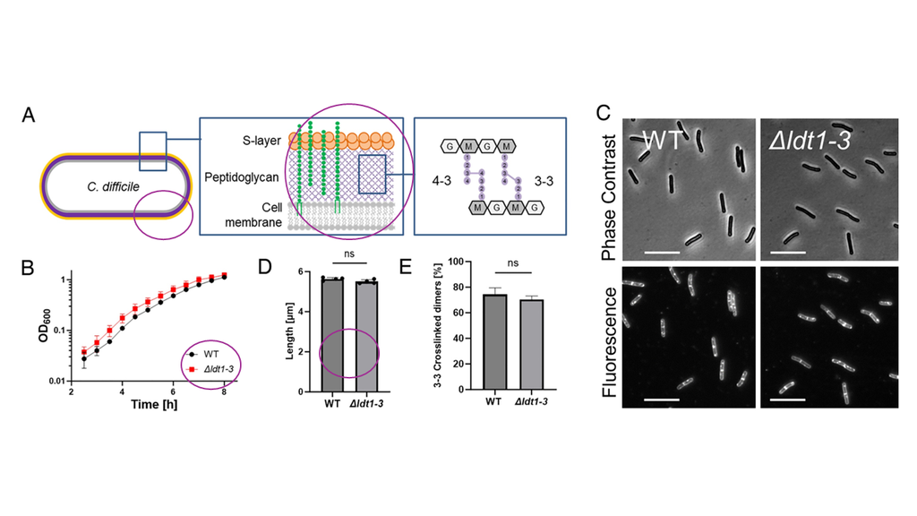